# Health and Economic Impact of Extreme Weather Events

Dave Yachabach

10/14/2020

# Synopsis

This document describes the health and economic impact of extreme weather events. The Health impact is measured in terms of casualties. Casualties are defined as death or injury as a result of a weather event.

Economic impact is expressed in Billions of dollars and is the combination of Property Damage and Crop Damage.

## Data Processing

The data for this document was originally obtained from the National Oceanic and Atmospheric Administration (NOAA) and was made available to this project through Coursera at https://d396qusza40orc.cloudfront.net/repdata%2Fdata%2FStormData.csv.bz2.

```r
# Load Data
bz2FilNm <- "repdata_data_StormData.csv.bz2"
dt <- fread(bz2FilNm)

# Get entries that caused casualties or economic impact
dtImpactData <- dt[FATALITIES > 0 | INJURIES > 0 | PROPDMG > 0 | CROPDMG>0,.(FATALITIES, INJURIES,PROPDMG, PROPDMGEXP, CROPDMG, CROPDMGEXP), by = "EVTYPE"]

# correct the value of the damages to Billions
# Correct the "K"
dtImpactData[PROPDMGEXP == "K",]$PROPDMG <- dtImpactData[PROPDMGEXP == "K",]$PROPDMG/1000000
dtImpactData[CROPDMGEXP == "K",]$CROPDMG <- dtImpactData[CROPDMGEXP == "K",]$CROPDMG/1000000

# Correct the "M"
dtImpactData[PROPDMGEXP == "M",]$PROPDMG <- dtImpactData[PROPDMGEXP == "M",]$PROPDMG/1000
dtImpactData[CROPDMGEXP == "M",]$CROPDMG <- dtImpactData[CROPDMGEXP == "M",]$CROPDMG/1000

# Sum to limit the rows
#
dtImpactTotals <- dtImpactData[,.(CASUALTIES = sum(FATALITIES,INJURIES), ECONOMIC = sum(PROPDMG, CROPDMG)), by = "EVTYPE"]
```

### Manipulations

Weather event data is filtered to only those events with economic or public health impact.

- Public health impact = Casualties (Fatality + Injury)
- Economic impact = Economic (Property + Crop damage)

This results in 488 categories of weather events.

### Cleaning and Consolidating

Economic data were expressed in two fields:

- PROPDMG and CROPDMG: Numeric - Indicates Amount
- PROPDMGEXP and CROPDMGEXP: Character - “K”, “M”, or “B”

Each entry was checked and corrected to “Billions”.

Data includes multiple names for similar storm types. These names were consolidated into 11 event categories. The table in Appendix 1 shows how public health threats were consolidated.

Additionally, Fatalities and Injuries were consolidated into Casualties; Property and Crop damage were consolidated into Economic.

```r
# Build lists of event descriptions
#

lstTSTMWEvent <- grep("THUND|TST", dtImpactTotals [,EVTYPE], value = TRUE)
lstTRNDOEvent <- grep("TORN|SPOUT|FUNN", dtImpactTotals $EVTYPE, value = TRUE)
lstWINDEvent <- grep("^HIGH WIND$|^HIGH WINDS*$", dtImpactTotals $EVTYPE, value = TRUE)
lstLTNGEvent <- grep("^[L].*G.*G", dtImpactTotals [,EVTYPE], value = TRUE)
lstHEATEvent <- grep("HEAT|WARM", dtImpactTotals [,EVTYPE], value = TRUE)
lstHRCNEvent <- grep("HUR|Hur|Typ|TYP|TROP|Trop", dtImpactTotals $EVTYPE, value = TRUE)
lstFLOODEvent <- grep("FLOO|Floo|FLA|Fla", dtImpactTotals $EVTYPE, value = TRUE)
lstCOLDEvent <- grep("COLD.*|Cold", dtImpactTotals $EVTYPE, value = TRUE)
lstWINTEREvent <- grep("WINT|Wint", dtImpactTotals $EVTYPE, value = TRUE)
lstSNOWEvent <- grep("SNOW", dtImpactTotals $EVTYPE, value = TRUE)
lstHAILEvent <- grep("HAIL", dtImpactTotals $EVTYPE, value = TRUE)
lstFIREEvent <- grep("FIRE", dtImpactTotals $EVTYPE, value = TRUE)
lstTIDEEvent <- grep("CURR|TIDE", dtImpactTotals $EVTYPE, value = TRUE)
lstFOGEvent <- grep("FOG", dtImpactTotals $EVTYPE, value = TRUE)
lstBLZEvent <- grep("BLI", dtImpactTotals $EVTYPE, value = TRUE)
lstICEEvent <- grep("ICE", dtImpactTotals $EVTYPE, value = TRUE)
lstSEAEvent <- grep("SEAS$|TIDE|CURR", dtImpactTotals $EVTYPE, value = TRUE)

# Then apply those descriptions to EVTYPE to summarize into EVENT categories

dtImpactTotals [,EVENT := "OTHER"]
dtImpactTotals [EVTYPE %in% lstTRNDOEvent, ]$EVENT = "TORNADO"
dtImpactTotals [EVTYPE %in% lstTSTMWEvent, ]$EVENT = "TSTMS/HAIL/LIGHTNING"
dtImpactTotals [EVTYPE %in% lstHAILEvent, ]$EVENT = "TSTMS/HAIL/LIGHTNING"
dtImpactTotals [EVTYPE %in% lstWINDEvent,]$EVENT = "WINDS"
dtImpactTotals [EVTYPE %in% lstLTNGEvent, ]$EVENT = "TSTMS/HAIL/LIGHTNING"
dtImpactTotals [EVTYPE %in% lstHEATEvent, ]$EVENT = "HEAT"
dtImpactTotals [EVTYPE %in% lstHRCNEvent, ]$EVENT = "HURRICANE"
dtImpactTotals [EVTYPE %in% lstFLOODEvent, ]$EVENT = "FLOOD"
dtImpactTotals [EVTYPE %in% lstCOLDEvent, ]$EVENT = "WINTER/COLD/SNOW"
dtImpactTotals [EVTYPE %in% lstWINTEREvent, ]$EVENT = "WINTER/COLD/SNOW"
dtImpactTotals [EVTYPE %in% lstSNOWEvent, ]$EVENT = "WINTER/COLD/SNOW"
dtImpactTotals [EVTYPE %in% lstBLZEvent,]$EVENT = "WINTER/COLD/SNOW"
dtImpactTotals [EVTYPE %in% lstICEEvent,]$EVENT = "WINTER/COLD/SNOW"
dtImpactTotals [EVTYPE %in% lstFIREEvent,]$EVENT = "WILDFIRE"
dtImpactTotals [EVTYPE %in% lstTIDEEvent,]$EVENT = "SEAS/TIDES"
dtImpactTotals [EVTYPE %in% lstFOGEvent,]$EVENT = "FOG"
```

# Results

## Public Health Impact

The graph below shows the relative public health hazard of the top 5 consolidated weather event categories since 1950:

```r
# We need top 5 casualty events
dtHealthTop5 <- dtImpactTotals[,.(CASUALTIES = sum(CASUALTIES)), by = "EVENT"]
setorder(dtHealthTop5, -CASUALTIES)
dtHealthTop5 <- dtHealthTop5[1:5,]
dtHealthTop5
```

```
##                   EVENT CASUALTIES
## 1:              TORNADO      97078
## 2: TSTMS/HAIL/LIGHTNING      17733
## 3:                 HEAT      12351
## 4:                FLOOD      10127
## 5:     WINTER/COLD/SNOW       7486
```

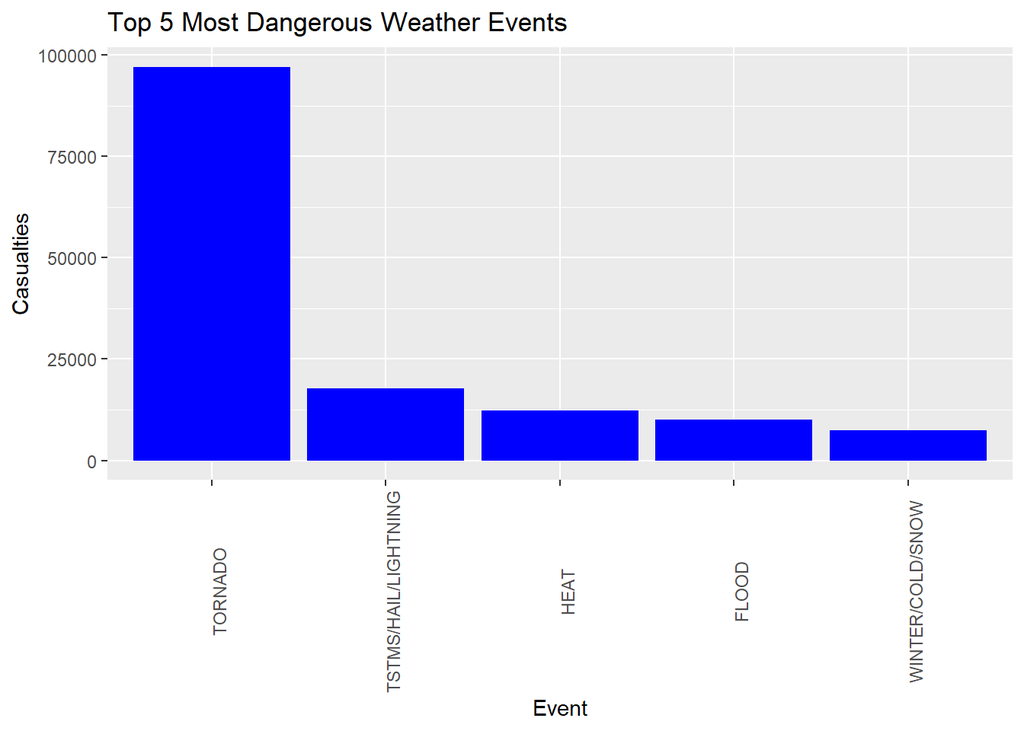

```r
# Now plot
g <- ggplot(data = dtHealthTop5)
ga <- g + aes(x = dtHealthTop5$EVENT, y = dtHealthTop5$CASUALTIES)
gag <- ga + geom_bar(stat = "identity", fill = "blue")
gagl <- gag + ggtitle ("Top 5 Most Dangerous Weather Events") + xlab("Event") + ylab("Casualties") + theme(legend.position = "none", axis.text.x = element_text(angle = 90))
gagl + scale_x_discrete(limits = dtHealthTop5$EVENT)
```

## Economic Impact

The graph below shows the relative economic hazard of the top 5 consolidated weather event categories since 1950:

```r
# Get top 5 Economic events
dtEconTop5 <- dtImpactTotals[,.(ECONOMIC_Blns = sum(ECONOMIC)), by = "EVENT"]
setorder(dtEconTop5, -ECONOMIC_Blns)
dtEconTop5 <- dtEconTop5[1:5,]
dtEconTop5
```

```
##                   EVENT ECONOMIC_Blns
## 1: TSTMS/HAIL/LIGHTNING     7515.8053
## 2:                FLOOD      801.6025
## 3:              TORNADO      527.6063
## 4:           SEAS/TIDES      154.6519
## 5:                WINDS      139.5577
```

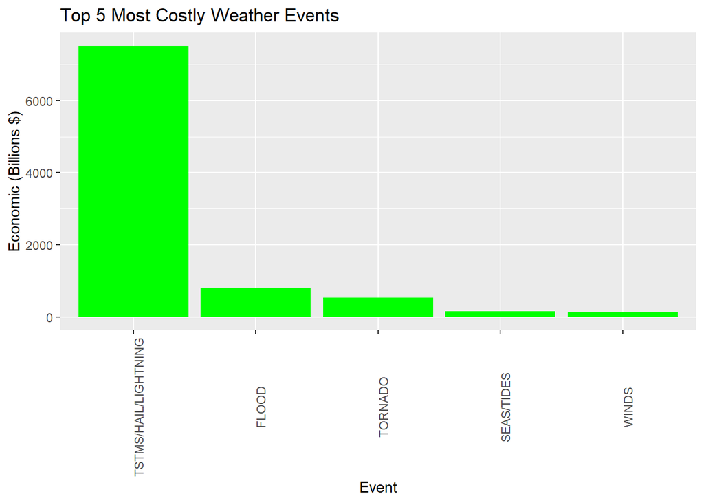

```r
# Now plot
g <- ggplot(data = dtEconTop5)
ga <- g + aes(x = dtEconTop5$EVENT, y = dtEconTop5$ECONOMIC_Blns)
gag <- ga + geom_bar(stat = "identity", fill = "green")
gagl <- gag + ggtitle ("Top 5 Most Costly Weather Events") + xlab("Event") + ylab("Economic (Billions $)") + theme(legend.position = "none", axis.text.x = element_text(angle = 90))
gagl + scale_x_discrete(limits = dtEconTop5$EVENT)
```

# Appendix 1

| EVENT | EVTYPE |
| --- | --- |
| TORNADO | TORNADO, TORNADO F0, WATERSPOUT, FUNNEL CLOUD, WATERSPOUT/TORNADO, WATERSPOUT TORNADO, WATERSPOUT-, WATERSPOUT-TORNADO, WATERSPOUT/ TORNADO, DUST DEVIL WATERSPOUT, TORNADO F3, TORNDAO, TORNADO F1, TOR… |
| TSTMS/HAIL/LIGHTNING | TSTM WIND, HAIL, THUNDERSTORM WINDS, LIGHTNING, THUNDERSTORM WIND, THUNDERSTORM WINS, THUNDERSTORM WINDS LIGHTNING, THUNDERSTORM WINDS/HAIL, LIGHTNING AND HEAVY RAIN, THUNDERSTORM WINDS HAIL, LIGHTNIN… |
| HEAT | HEAT, EXCESSIVE HEAT, HEAT WAVE, UNSEASONABLY WARM, EXTREME HEAT, DROUGHT/EXCESSIVE HEAT, RECORD HEAT, HEAT WAVE DROUGHT, HEAT WAVES, UNSEASONABLY WARM AND DRY, RECORD/EXCESSIVE HEAT, WARM WEATHER |
| FLOOD | FLASH FLOODING, FLASH FLOOD, FLASH FLOODING/THUNDERSTORM WI, FLOODING, BREAKUP FLOODING, RIVER FLOOD, COASTAL FLOOD, FLOOD, FLOODING/HEAVY RAIN, HEAVY SURF COASTAL FLOODING, FLOOD/FLASH FLOOD, FLOOD/R… |
| WINTER/COLD/SNOW | ICE STORM/FLASH FLOOD, WINTER STORM, COLD, EXTREME COLD, HEAVY SNOW, HEAVY SNOW/WIND, ICE STORM, WINTER STORM HIGH WINDS, WINTER STORMS, HEAVY SNOWPACK, BLIZZARD, SNOW, FREEZING RAIN/SNOW, THUNDERSNOW… |
| HURRICANE | HURRICANE OPAL/HIGH WINDS, HURRICANE ERIN, HURRICANE OPAL, TROPICAL STORM ALBERTO, TROPICAL STORM, TROPICAL STORM GORDON, TROPICAL STORM JERRY, HURRICANE, HURRICANE-GENERATED SWELLS, HURRICANE EMILY, … |
| WINDS | HIGH WINDS, HIGH WIND |
| WILDFIRE | WILD FIRES, WILDFIRE, GRASS FIRES, LIGHTNING FIRE, FOREST FIRES, WILDFIRES, WILD/FOREST FIRE, WILD/FOREST FIRES, BRUSH FIRE |
| SEAS/TIDES | RIP CURRENT, HIGH TIDES, RIP CURRENTS/HEAVY SURF, RIP CURRENTS, ASTRONOMICAL HIGH TIDE, STORM SURGE/TIDE, ASTRONOMICAL LOW TIDE |
| FOG | DENSE FOG, FOG, FOG AND COLD TEMPERATURES, FREEZING FOG |
| OTHER | HEAVY RAIN, WIND, HEAVY RAINS, HEAVY RAIN/LIGHTNING, FREEZE, HIGH WINDS HEAVY RAINS, AVALANCHE, MARINE MISHAP, HIGH WIND/SEAS, HIGH WINDS/HEAVY RAIN, HIGH SEAS, SEVERE TURBULENCE, RECORD RAINFALL, DUS… |